# Sintaxis

### Vector

Una de las posibildades de crear un vector es utilizar la orden **c()**:

```r
x <- c(0.5, 0.6) # numérico
x <- c(TRUE, FALSE) # lógico
x <- c(T, F) ## logical
x <- c("a", "b", "c") # caracter
x <- c(1, 2, 3, 4) # entero
x <- c(1+0i, 2+4i) # complejo
```

Para crear un vector que contenga una secuencia de números, podemos hacerlo de diferentes maneras:

```r
x <- c(1, 2, 3, 4, 5, 6, 7, 8, 9, 10)
x <- 1:10 # otra manera de crear el mismo vector
x <- seq(1, 10, 1) # la función seq puede crear
                   # secuencias de n° reales
x <- vector(mode = "numeric", length = 5) # vector numérico con 0 de longitud 5.
```

Creamos un vector de factores:

```r
x <- factor(c("si", "si", "no", "si", "no"))

table(x) # con la función "table" armamos una tabla de frecuencias.
```

```
## x
## no si
##  2  3
```

```r
unclass(x) # visualizamos el vector sin las etiquetas
```

Podemos colocar el orden de niveles del factor utilizando la orden levels()

```r
x <- factor(c("si", "si", "no", "si", "no"), levels = c("si", "no"))
```

### Ejercicios con vectores

2. Construir un vector del 1 al 10 y guardarlo en una variable “x”
3. Construir un vector del 1 al 20, cada dos unidades y guardarlo en una variable “y”.
4. Sumar “x” con “y”.
5. Restarle al vector “y” las primeras dos posiciones del vector “x”.
6. Agregarle al vector “x” los valores de “y” que sean mayores a 5 y guardarlo en una nueva variable.
7. Eliminar la primera posición del vector y.
8. Sumar todos los valores de “y” menos el último.
9. Agregarle un Na al vector “x” en las posiciones 8 y 9.

### Ejercicios con caracteres

1. Guardar la palabra ¡Visualizacion! en un objeto
2. Crear un objeto llamada “colores” que contenga un vector con las cadenas “rojo”, “azul”, “verde”, “azul”, “rojo”.
3. Aumentar la longitud del vector “colores” a 10.
4. Crear un vector de factores de 50 elementos que contenga las 5 “V” de Big data, cada uno de ellos 10 veces.

### Matrices

Cuando se crean matrices se debe indicar el número de filas y el número de columnas requeridos. Por ejemplo:

```r
m <- matrix(nrow = 2, ncol = 3)
m # visualizamos la matriz
dim(m) # verificamos las dimensiones de la matriz
```

En este caso se creó una matriz con 2 filas y 3 columnas pero sin datos

Podemos crear una matriz con datos de la siguiente manera:

```r
m <- matrix(1:6, nrow = 2, ncol = 3)
m # visualizamos la matriz
```

La matriz se completa columna por columna de izquierda a derecha.

### Arreglos (array)

Para crear un arreglo de dimensión 3x3x2 que contiene los números del 1 al 18, procedemos de la siguiente manera:

```r
arreglo <- array(c(1, 2, 3, 4, 5, 6, 7, 8, 9, 10, 11, 12,
                   13,14, 15, 16, 17, 18), dim=c(3, 3, 2))
```

### Listas

```r
lista <- list(Numeros = 1:5, Cadena = c("Hola", "Hola"),
              Matriz = matrix(1:6, nrow = 2, ncol = 3))
```

Se puede crear una lista de listas.

```r
lista_1 <- list(lista, lista)
lista_1
```

### Data frames

- Son representados como un tipo especial de lista donde cada elemento de la lista debe tener la misma longitud.
- Cada elemento de la lista puede ser pensado como una columna y la longitud de cada elemento de la lista es el número de filas.
- Diferente a las matrices, los data frames pueden cargar diferentes clases de objetos en cada columna, similar a las listas como fue mencionado anteriormente; las matrices deben tener los elementos de la misma clase.

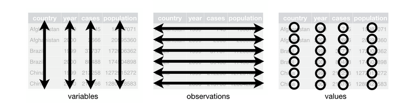

Ejemplo para crear un dataframe

```r
df <- data.frame(Fruta = c("manzana", "pera",
                            "banana", "ciruela"),
                            Cantidad = 1:4)
```

Diferentes funciones para extraer información del dataframe:

```r
nrow(df)  # observamos el número de filas.
ncol(df)  # observamos el número de columnas.
colnames(df) # solicitamos los nombres de las columnas.
row.names(df) # solicitamos los nombres de las filas.
```

## Atributos

Los objetos de R tienen atributos:

- Nombres, dimnames
- Dimensiones (ej. matrices, arreglos)
- Clase
- Longitud
- Otros que pueden ser definidos por el usuario.

La función **attributes()** detalla algunos de los atributos de un objeto.